# SY19 A19 TP7 Rapport

YUHUI WANG, XINGJIAN ZHOU et AGHILES HAMACHE

12 Janvier,2020

# 1. Partie Classification

## 1.1 Introduction

Dans ce problème de classification, nous devons classifier les 3 différents types d’objets astronomiques à partir de 17 variables. Pour cette partie nous avons fait les analyses ci-dessous :  
- PCA  
- K plus proche voisins  
- Analyse discriminante quadratique (QDA) - Logistic Regression  
- Classification naive bayésienne  
- Arbre de décision avec application du bagging et des forêts aléatoires  
- KSVM  
- Neural Network simple avec une seule couche cachée

## 1.2 Préparation, traitement des données

Avant commencer, nous faisons le traitement des données pour que notre algorithmes puissent fonctionner mieux. Et pour les algorithmes basés sur des arbres, nous prenons les données d’orgine, en raison qu’ils n’ont pas besoin de traitement des données.

Tout d’abord, nous fasions l’analyse de données. Sachant que la colonne *rerun* et la colonne *objid* sont identiques pour tous les données, nous supprimons ces deux colonnes.

Deuxièmement, vue que la variable *specobjid* est trop grande au nivaeau de 10<sup>18</sup>, et *redshift* est trop petite au niveau de 10<sup>-5</sup>. Dans ce condition là, pour équilibrer l’influence des variables différentes, nous utilisons la fonction **scale()** pour normaliser tous les variables.

Troisièmement, nous analysons la dépendence entre les variables en calculant leur covariance. La fonction **corr.test()** de package `psych` est utilisée pour ganer une matrice de corrélation ainsi qu’une matrice des p-values. Et la fonction **corrplot()** du package `corrplot` sert à visualiser graphiquement la matrice de corrélation.

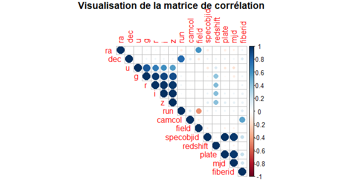

D’après la matrice des p-values et la figure des valeurs corrélation, nous pouvons voir clairement que deux groupes des valeurs *u,g,r,i,z* et *plate,mjd,specobjid* ont une relation linéaire entre eux. Donc nous pouvons prévoir que les méthodes pour réduire la dimension des features seront utiles pour les algorithms qui font hypothèses que les features n’ont pas de relation linéaire. Ainsi nous choissisons de faire l’analyse en composant principal pour l’extraction des features, en utilisant la fonction **prcomp()**.

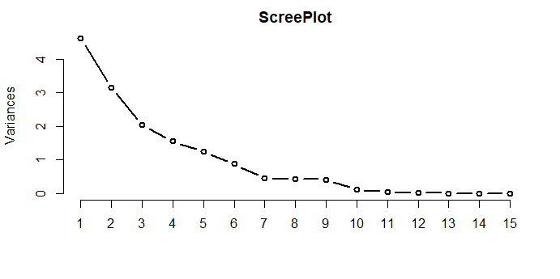

Nous pouvons faire la conclusion de la figure de **ScreePlot** que nous pouvons choisir les 10 premiers composants principals, et la proportion cumulative est au 0.99521.

Pour pouvoir comparer plus facilement tous les algorithmes, nous utilisons la validation croisée de K-fold. Et après,nous faisons l’intervalle de confiance approximative au nivau 95% avec l’erreurs obtenues en utilisant la fonction **t.test()**.

## 1.3 Sélection de modèle

### 1.3.1 Logistic Regression

D’abord, nous faisons la méthode logistic regression, qui est un algorithme très simple pour le problème de classification, en utilisant la fonction **multinom()** de package `nnet` pour la condition avec 3 types.

```
## Erreur au moyen de logistic regression = 0.016     IC = [ 0.01306016 0.01893984 ]
```

### 1.3.2 QDA

Puis nous utilisons le modèle QDA par la fonction **qda()** dans le package `MASS`. On trouve que logistic regression fonctionne mieux que QDA.

```
## Erreur au moyen de QDA = 0.0232     IC = [ 0.01861576 0.02778424 ]
```

### 1.3.3 KNN

Pour la méthode de KNN, nous retiendrons la classe la plus représentée parmi les k sorties associées aux k entrées les proches de la nouvelle entrée x. Premièrement, nous appliquons la méthode de la validation croisée pour obtenir un meilleur k. Par la méthode CV, le taux d’erreur reste presque invariant pour k entre 1 et 500. Donc, on choisissons alors K=100.

```
## Erreur au moyen de knn = 0.1132     IC = [ 0.1015925 0.1248075 ]
```

### 1.3.4 Naive Bayes

Pour cette méthode, nous faisons la modélisation en utilisant la fonction **naiveBayes()** dans le package `E1071`.

```
## Erreur au moyen de naive bayes = 0.1362     IC = [ 0.1241455 0.1482545 ]
```

### 1.3.7 Neural Network

Pour le neural network, nous chosissons le moddèle simple avec une seule couche cachée qui contient 15 noeuds dedans. Et nous le réalisons avec **nnet()** dans le package `nnet`.